# python_lecture_1 slides

## Software Carpentry - Python part 1

09:00 - Introduction to Jupyter notebooks  
09:15 - Python fundamentals  
09:40 - **Exercises**  
10:00 - Loading and analysing data

**10:15 - Coffee break**

10:30 - Visualizing data  
10:45 - **Exercises**

**11:30 - Lunch break**

12:00 - Repeating actions  
12:30 - **Exercises**

13:00 - Wrap up

# Anaconda

Anaconda Navigator is a graphical user interface to the conda package and environment manager and a free scientific-computing environment.

## Installation comes with:

- Latest version of Python
- JupyterLab, Jupyter notebooks and several other IDE options
- An easy-to-install collection of high performance Python libraries
- Conda, tool for managing packages and environments
- Collection of open source packages and tools to install over 1.5k additional packages

[figure not shown]

## Jupyter Notebook

Jupyter Notebook is a **free, open-source, interactive web tool** known as a computational notebook, which researchers can use to combine code, computational output, text and multimedia resources in a single document.

You can think of them as laboratory notebooks for scientific computing. The notebook can "speak" dozens of programming languages — reflected in its name inspired by the programming languages Julia (Ju), Python (Py) and R.

Analysis of the code-sharing site GitHub counted more than **2.5 million public Jupyter notebooks** in September 2018, up from 200,000 in 2015.

Example: [Gravitational Wave Open Science Center](https://mybinder.org/v2/gh/losc-tutorial/quickview/master?filepath=index.ipynb)

## Jupyter notebooks are useful for...

- Really good for linear workflows (e.g. read data, filter data, do some statistics, plot the results)
- Sharing and explaining code to colleagues
- As an interactive development environment for code, data analysis, and visualization
- Prototyping: setting up an interactive environment to execute code, see what happens, modify and repeat
- creating tutorials or interactive manuals for communicating data analysis routines
- Slide presentations (including this one)

## Pitfalls

- Non-linear code flow
- Large code-base (notebooks can be an entrypoint though)
- Limitations in version control (mostly resolved now)

# Let's open up Jupyter Lab!

[figure not shown]

# 1. Python fundamentals

### Key points

- Basic data types in Python include integers, strings, and floating-point numbers.
- Use `variable = value` to assign a value to a variable.
- Use `print(something)` to display the value of `something`.
- `[value1, value2, value3]` creates a list.
- Lists can contain any Python object, including lists (i.e., list of lists).
- Lists are indexed and sliced with square brackets.
- Array indices start at 0 (not 1).

### Questions?

# Our case study

### Arthritis Inflammation

We are studying inflammation in patients who have been given a new treatment for arthritis.

There are 60 patients, who had their inflammation levels recorded for 40 days. We want to analyze this data to study the effect of the new arthritis treatment.

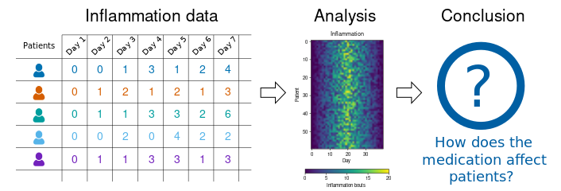

What if we need the maximum inflammation for each patient over all days (as in the next diagram on the left) or the average for each day (as in the diagram on the right)?

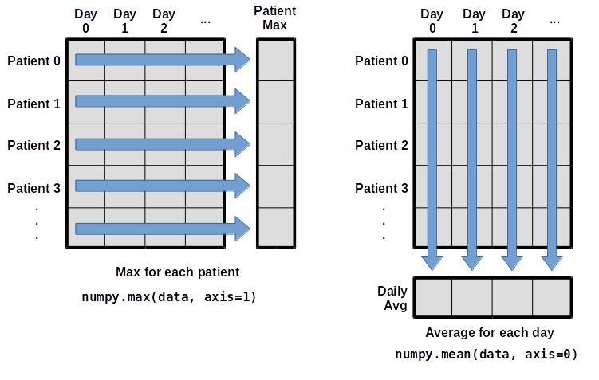

# 2. Analysing patient data

### Key points

- Import a library into a program using import `library_name`.
- Use the `numpy` library to work with arrays/matrices in Python.
- Use array `[x, y]` to select a single element from a 2D array.
- Use `numpy.mean(array)`, `numpy.max(array)`, and `numpy.min(array)` to calculate basic statistics.
- Use `numpy.mean(array, axis=0)` or `numpy.mean(array, axis=1)` to calculate statistics across the specified axis.

### Questions?

# 3. Visualizing Tabular Data

### Key points

- Use the `pyplot` module from the `matplotlib` library for creating simple visualizations.
- Use an alias when importing lengthy library names, e.g. `import matplotlib.pyplot as plt`
- Create subplots and add labels

### Questions?

# 4. Repeating actions

### Key points

- Use `for variable in sequence:` to process the elements of a sequence one at a time.
- The body of a `for` loop must be indented.
- Use `glob.glob(pattern)` to create a list of files whose names match a pattern.
- Use `*` in a pattern to match zero or more characters, and `?` to match any single character.